# 320 Final Project

Amy, Katie, Shawdi

5/11/2019

## R Markdown

```r
library(rvest)
library(tidyverse)
url <-"html_top100.txt"
college_urls <- url %>%
  read_html() %>%
  html_node("body") %>% html_nodes("ol[class~=bEyEue]") %>% html_nodes("li[id]")%>% html_nodes("h3") %>%
  html_nodes("a[href]") %>%
  html_attr("href")
head(college_urls)
```

```
## [1] "/best-colleges/princeton-university-2627"
## [2] "/best-colleges/harvard-university-2155"
## [3] "/best-colleges/columbia-university-2707"
## [4] "/best-colleges/massachusetts-institute-of-technology-2178"
## [5] "/best-colleges/university-of-chicago-1774"
## [6] "/best-colleges/yale-university-1426"
```

```r
index_num <- 0

college_tab_1 <-  data.frame("URL" = gsub(" ", "", paste("https://www.usnews.com",college_urls, sep = "")),
"CollegeName"= "", "TuitionFeesThousands" = 0, "RoomBoardThousands" = 0, "TotalEnrollment" = 0, "SchoolType" = "", "YearFounded" = 0, "Setting" = "", "Endowment2017Millions" = 0, "MedianStartingSalaryOfAlumniThousands" = 0, "Selectivity" = "", "Fall2017AcceptanceRate" = 0, "MalePercentage" = 0, "FourYearGraduationRate" = 0, stringsAsFactors = FALSE)

#removing one college that doesn't have a median starting salary, for data uniformity
college_tab_1 <- college_tab_1[-c(40),]

head(college_tab_1)
```

```
##                                                                               URL
## 1                  https://www.usnews.com/best-colleges/princeton-university-2627
## 2                    https://www.usnews.com/best-colleges/harvard-university-2155
## 3                   https://www.usnews.com/best-colleges/columbia-university-2707
## 4 https://www.usnews.com/best-colleges/massachusetts-institute-of-technology-2178
## 5                 https://www.usnews.com/best-colleges/university-of-chicago-1774
## 6                       https://www.usnews.com/best-colleges/yale-university-1426
##   CollegeName TuitionFeesThousands RoomBoardThousands TotalEnrollment
## 1                                0                  0               0
## 2                                0                  0               0
## 3                                0                  0               0
## 4                                0                  0               0
## 5                                0                  0               0
## 6                                0                  0               0
##   SchoolType YearFounded Setting Endowment2017Millions
```

[output cut: 20 more lines]

Below are functions used to obtain data from the website and parse it.

```r
#retrieves of vector of size three containing the Tuition&Fees, Room&Board, and total enrollment
get_info <- function(url_html){
  attr <- url_html %>% html_node("body") %>% html_nodes("div[id~=content-main]") %>%
    html_nodes("section[class~=hero-stats-widget-stats]") %>%
    html_nodes("ul") %>% html_nodes("li") %>% html_nodes("strong")
}

#takes in a vector and index, and parses that information to a double
#ex: $47,263 -> 47263.0
get_tuition_rm <- function(info, num){
  a_1 <- info[num] %>%  html_text()
  tuition_rm <-
    as.double(paste(substring(a_1, 2, str_locate(a_1, ",")[1] - 1), substring(a_1, str_locate(a_1, ",")[1] + 1, str_locate(a_1, " ")[1] - 1), sep=""))
  tuition_rm / 1000.0
}

#takes in a vector and parses the total enrollment information to a double
get_enrollment <- function(info){
  a_1 <- info[3] %>%  html_text()
  as.double(paste(substring(a_1, 1, str_locate(a_1, ",")[1] - 1), substring(a_1, str_locate(a_1, ",")[1] + 1), sep=""))
}

#gets the percentage of the majority gender at a certain university
get_percent <- function(url_html){
  attr <- url_html %>% html_node("body") %>% html_nodes("div[id~=content-main]") %>%
    html_nodes("div[class~=block-normal]") %>% html_nodes("span[class~=distribution-breakdown__percentage]") %>% html_text()
  as.double(substring(attr, 1, str_locate(attr, "%")[1] - 1)) / 100.0
}

#retrieves the gender of the majority sex and parses the percentage to be in terms of males
get_gender_ratio <- function(url_html){
  attr <- url_html %>% html_node("body") %>% html_nodes("div[id~=content-main]") %>%
    html_nodes("div[class~=block-normal]") %>% html_nodes("span[class~=distribution-breakdown__percentage-copy]") %>% html_text()
  attr <- sub("\n                    ","",attr)
  attr <- sub("\n                ","",attr)
  if (attr == "Female"){
    1 - get_percent(url_html)
  }else{
    get_percent(url_html)
  }
}
```

Here, we use both the functions above and the html_node function to fill out the table.

```r
college_tab <- college_tab_1

for (i in 1:nrow(college_tab)){
  url_html <- college_tab[i,1] %>%read_html()
  college_tab[i,]$CollegeName <- url_html %>% html_node("body") %>% html_nodes("h1[class~=hero-heading]") %>% html_text()
  priv_tuition <- url_html %>% html_node("body") %>% html_nodes("span[data-test-id~=v_private_tuition]") %>% html_text()
  college_tab[i,]$TuitionFeesThousands <- ifelse(length(priv_tuition) > 0, priv_tuition,
                                                 url_html %>% html_node("body") %>% html_node("span[data-test-id~=v_out_state_tuition]") %>% html_text())
  college_tab[i,]$RoomBoardThousands <- url_html %>% html_node("body") %>% html_node("span[data-test-id~=w_room_board]") %>% html_text()
  college_tab[i,]$TotalEnrollment <- url_html %>% html_node("body") %>% html_node("span[data-test-id~=total_all_students]") %>% html_text()
  college_tab[i,]$MalePercentage <- get_gender_ratio(url_html)
  college_tab[i,]$Fall2017AcceptanceRate <- url_html %>% html_node("span[data-test-id~=r_c_accept_rate]") %>% html_text()
  college_tab[i,]$Selectivity <- url_html %>% html_node("span[data-test-id~=c_select_class]") %>% html_text()
  college_tab[i,]$FourYearGraduationRate <- url_html %>% html_node("span[data-test-id~=grad_rate_4_year]") %>% html_text()
  college_tab[i,]$MedianStartingSalaryOfAlumniThousands <-  url_html %>% html_nodes("div[data-field-id=averageStartSalary]") %>%html_node("span[data-test-id]") %>% html_text()
  temp_vector <- url_html %>% html_node("body") %>% html_nodes("div[id~=content-main]") %>%html_nodes("div[class~=flex-row]") %>%   html_nodes("span[class~=heading-small]") %>% html_text()
  college_tab[i,]$SchoolType <- temp_vector[1]
  college_tab[i,]$YearFounded <- temp_vector[2]
  college_tab[i,]$Setting <- temp_vector[5]
  college_tab[i,]$Endowment2017Millions  <- temp_vector[6]
}

head(college_tab)
```

```
##                                                                               URL
## 1                  https://www.usnews.com/best-colleges/princeton-university-2627
## 2                    https://www.usnews.com/best-colleges/harvard-university-2155
## 3                   https://www.usnews.com/best-colleges/columbia-university-2707
## 4 https://www.usnews.com/best-colleges/massachusetts-institute-of-technology-2178
## 5                 https://www.usnews.com/best-colleges/university-of-chicago-1774
## 6                       https://www.usnews.com/best-colleges/yale-university-1426
##                                             CollegeName
## 1                  \n        Princeton University\n
## 2                    \n        Harvard University\n
## 3                   \n        Columbia University\n
## 4 \n        Massachusetts Institute of Technology\n
## 5                 \n        University of Chicago\n
## 6                       \n        Yale University\n
##              TuitionFeesThousands              RoomBoardThousands
```

[output cut: 34 more lines]

Below, we reformat many of the columns to get usable data.

```r
formatted_college_tab <- college_tab
#fix type of School Type, Setting, Year Founded
formatted_college_tab$SchoolType <- as.factor(formatted_college_tab$SchoolType)
formatted_college_tab$Setting <- as.factor(formatted_college_tab$Setting)
formatted_college_tab$YearFounded <- as.integer(formatted_college_tab$YearFounded)

#fix Endowment2017 formatting
formatted_college_tab$Endowment2017Millions  <- ifelse(grepl("billion", formatted_college_tab$Endowment2017Millions ), sub("\\.","",formatted_college_tab$Endowment2017Millions ),formatted_college_tab$Endowment2017Millions )
formatted_college_tab$Endowment2017Millions  <-sub(" billion","00",formatted_college_tab$Endowment2017Millions )
formatted_college_tab$Endowment2017Millions  <-sub(" million","",formatted_college_tab$Endowment2017Millions )
formatted_college_tab$Endowment2017Millions  <-sub("[[:punct:]]", "",formatted_college_tab$Endowment2017Millions )
formatted_college_tab$Endowment2017Millions  <-sub("\\$", "",formatted_college_tab$Endowment2017Millions )
formatted_college_tab$Endowment2017Millions  <-sub(" \\+", "",formatted_college_tab$Endowment2017Millions )
#fix College Name formatting
formatted_college_tab$CollegeName <- sub("^\n        ","",formatted_college_tab$CollegeName)
formatted_college_tab$CollegeName <-sub("\n    ","",formatted_college_tab$CollegeName)
#fixing Acceptance Rate formatting
formatted_college_tab$Fall2017AcceptanceRate <- sub("\n            ","",formatted_college_tab$Fall2017AcceptanceRate)
formatted_college_tab$Fall2017AcceptanceRate <- sub("%","",formatted_college_tab$Fall2017AcceptanceRate)
formatted_college_tab$Fall2017AcceptanceRate <- as.double(formatted_college_tab$Fall2017AcceptanceRate)
formatted_college_tab$Fall2017AcceptanceRate <- formatted_college_tab$Fall2017AcceptanceRate/100
#fixing Grad Rate formatting
formatted_college_tab$FourYearGraduationRate <- sub("\n            ","",formatted_college_tab$FourYearGraduationRate)
formatted_college_tab$FourYearGraduationRate <- sub("%","",formatted_college_tab$FourYearGraduationRate)
formatted_college_tab$FourYearGraduationRate <- as.double(formatted_college_tab$FourYearGraduationRate)
formatted_college_tab$FourYearGraduationRate <- formatted_college_tab$FourYearGraduationRate/100
#fixing Salary formatting
formatted_college_tab$MedianStartingSalaryOfAlumniThousands <-
  sub("\n            ","",formatted_college_tab$MedianStartingSalaryOfAlumniThousands)
formatted_college_tab$MedianStartingSalaryOfAlumniThousands <- gsub("\\*","",formatted_college_tab$MedianStartingSalaryOfAlumniThousands)
formatted_college_tab$MedianStartingSalaryOfAlumniThousands <- gsub("\\$","",formatted_college_tab$MedianStartingSalaryOfAlumniThousands)
formatted_college_tab$MedianStartingSalaryOfAlumniThousands <- gsub("\\,","",formatted_college_tab$MedianStartingSalaryOfAlumniThousands)
formatted_college_tab$MedianStartingSalaryOfAlumniThousands <- as.double(formatted_college_tab$MedianStartingSalaryOfAlumniThousands)/1000
#fixing Selectivity formatting
formatted_college_tab$Selectivity <- sub("\n            ","",formatted_college_tab$Selectivity)
formatted_college_tab$Selectivity <- as.factor(formatted_college_tab$Selectivity)
#fixing Tuition formatting
formatted_college_tab$TuitionFeesThousands <- sub("\n            ", "",formatted_college_tab$TuitionFeesThousands )
formatted_college_tab$TuitionFeesThousands <- sub(" \\(2018-19\\)", "",formatted_college_tab$TuitionFeesThousands )
formatted_college_tab$TuitionFeesThousands  <-sub("\\,", "",formatted_college_tab$TuitionFeesThousands )
formatted_college_tab$TuitionFeesThousands  <-sub("\\$", "",formatted_college_tab$TuitionFeesThousands )
formatted_college_tab$TuitionFeesThousands <- as.double(formatted_college_tab$TuitionFeesThousands)/1000
#fixing RoomBoard formatting
formatted_college_tab$RoomBoardThousands <- sub("\n            ", "",formatted_college_tab$RoomBoardThousands )
formatted_college_tab$RoomBoardThousands <- sub(" \\(2018-19\\)", "",formatted_college_tab$RoomBoardThousands )
formatted_college_tab$RoomBoardThousands  <-sub("\\,", "",formatted_college_tab$RoomBoardThousands )
formatted_college_tab$RoomBoardThousands  <-sub("\\$", "",formatted_college_tab$RoomBoardThousands )
formatted_college_tab$RoomBoardThousands <- as.double(formatted_college_tab$RoomBoardThousands)/1000
#fixing Enrollment formatting
formatted_college_tab$TotalEnrollment <- sub("\n            ", "",formatted_college_tab$TotalEnrollment )
formatted_college_tab$TotalEnrollment  <-sub("\\,", "",formatted_college_tab$TotalEnrollment )
formatted_college_tab$TotalEnrollment <- as.double(formatted_college_tab$TotalEnrollment)


formatted_college_tab <- formatted_college_tab %>% mutate(TotalCostThousands =TuitionFeesThousands + RoomBoardThousands )

head(formatted_college_tab)
```

```
##                                                                               URL
## 1                  https://www.usnews.com/best-colleges/princeton-university-2627
## 2                    https://www.usnews.com/best-colleges/harvard-university-2155
## 3                   https://www.usnews.com/best-colleges/columbia-university-2707
## 4 https://www.usnews.com/best-colleges/massachusetts-institute-of-technology-2178
## 5                 https://www.usnews.com/best-colleges/university-of-chicago-1774
## 6                       https://www.usnews.com/best-colleges/yale-university-1426
##                             CollegeName TuitionFeesThousands
## 1                  Princeton University               47.140
## 2                    Harvard University               50.420
## 3                   Columbia University               59.430
## 4 Massachusetts Institute of Technology               51.832
## 5                 University of Chicago               57.006
## 6                       Yale University               53.430
##   RoomBoardThousands TotalEnrollment    SchoolType YearFounded  Setting
```

[output cut: 27 more lines]

# r EDAvisualization

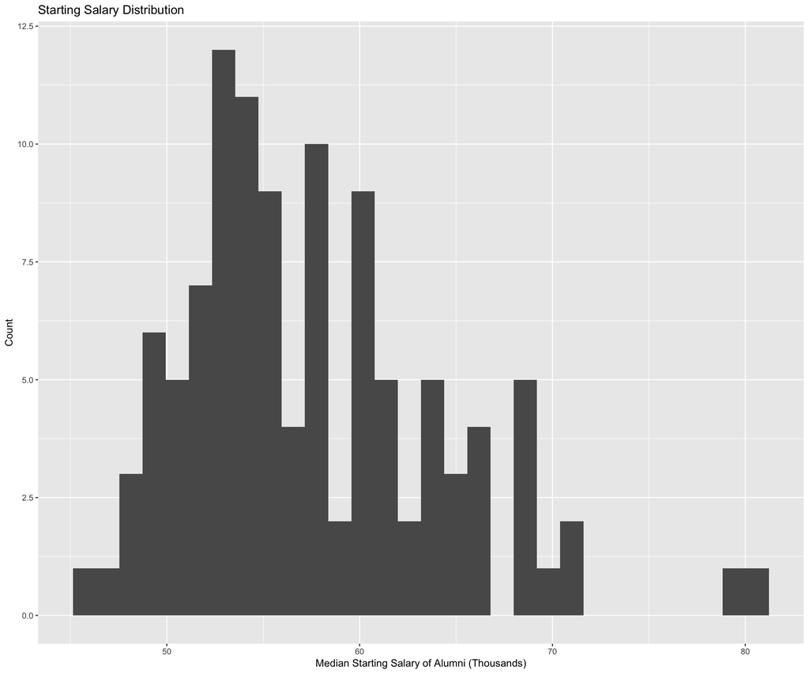

```r
#Starting Salary
#-histograms
library(ggplot2)
plot_1 <- formatted_college_tab %>%
  ggplot(aes(MedianStartingSalaryOfAlumniThousands)) +
    geom_histogram()+
    labs(title="Starting Salary Distribution", x="Median Starting Salary of Alumni (Thousands)", y="Count")
plot_1
```

The distribution of the median starting salary of alumni from all the school seems to be a bell-shaped curve, centering around $55,000.

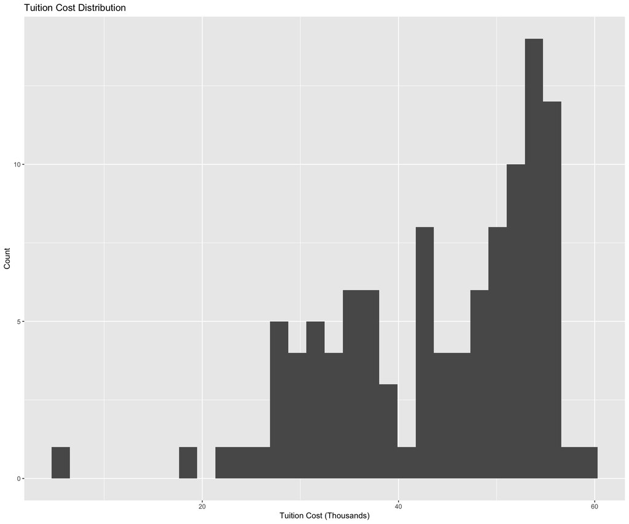

```r
#Tuition Cost
#-histograms
library(ggplot2)
plot_2 <- formatted_college_tab %>%
  ggplot(aes(TuitionFeesThousands)) +
    geom_histogram()+
        labs(title="Tuition Cost Distribution", x="Tuition Cost (Thousands)", y="Count")
plot_2
```

The distribution of tution costs of all the schools is bimodal, with a range of $60,000.

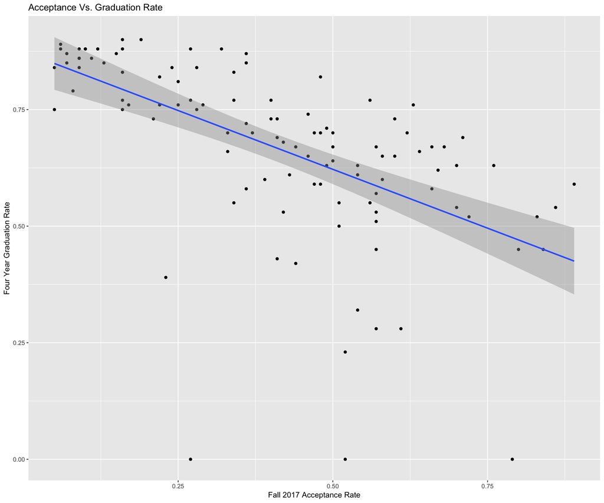

```r
#Acceptance rate vs graduation rate

library(ggplot2)
plot_3 <- formatted_college_tab %>%
  ggplot(aes(x=Fall2017AcceptanceRate, y=FourYearGraduationRate)) +
    geom_point()+
    geom_smooth(method=lm)+
        labs(title="Acceptance Vs. Graduation Rate", x="Fall 2017 Acceptance Rate", y="Four Year Graduation Rate")
plot_3
```

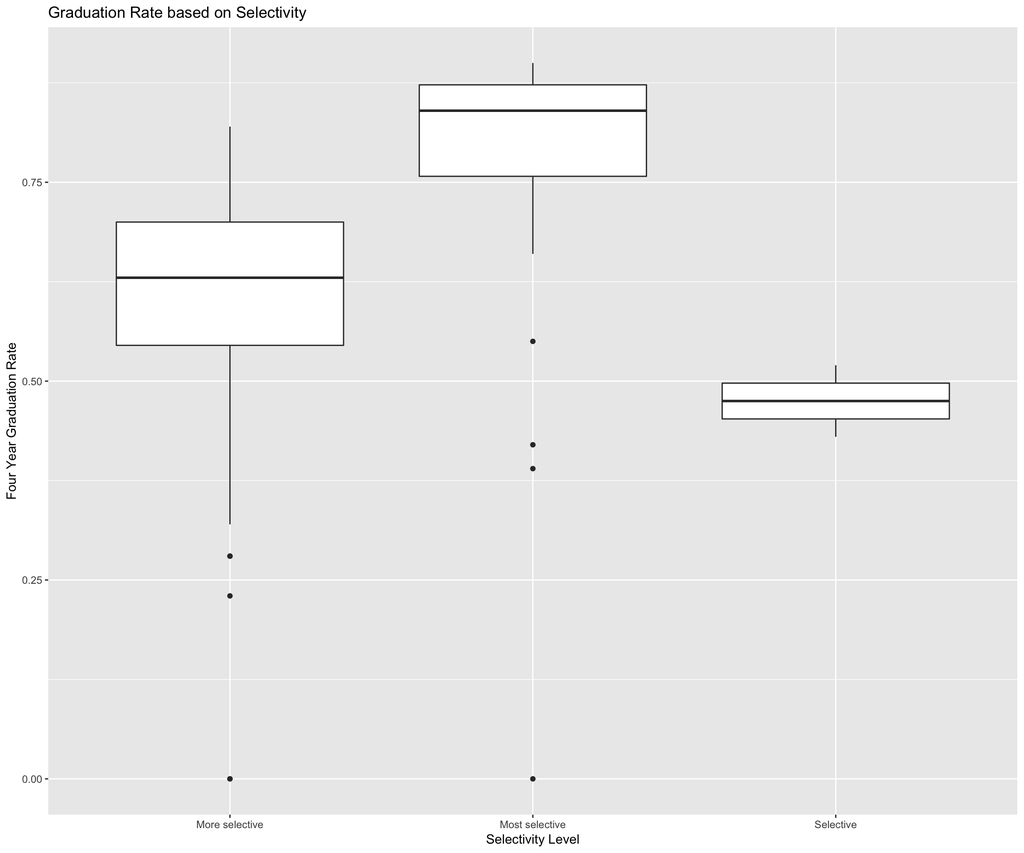

```r
#Boxplots of (1) gradrate & (2) admission rate by selectivity

library(ggplot2)
plot_4 <- formatted_college_tab %>%
  ggplot(aes(x=Selectivity, y=FourYearGraduationRate)) +
    geom_boxplot()+
        labs(title="Graduation Rate based on Selectivity", x="Selectivity Level", y="Four Year Graduation Rate")
plot_4
```

This is significant difference in four year graduation rates based on their Selectivity Level of accepting students. These boxplots show that each 3 selectivity level vary significantly on range and central tendency. The more selective a college is, the greater their graduation rates seem to be.

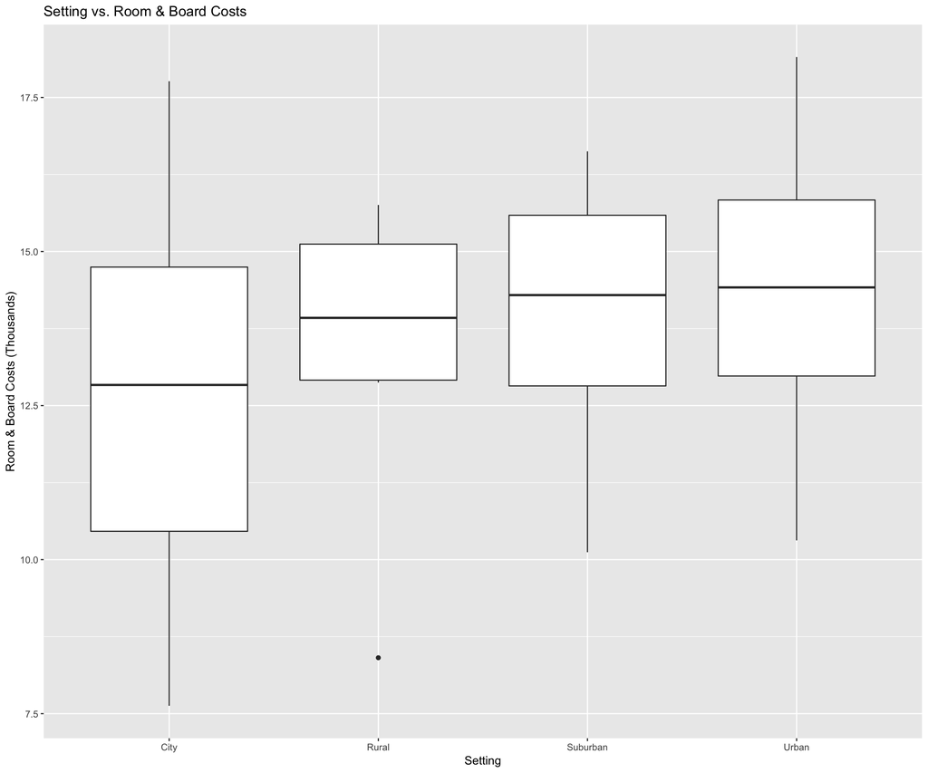

```r
#Setting vs. room board

library(ggplot2)
plot_5 <- formatted_college_tab %>%
  ggplot(aes(x=Setting, y=RoomBoardThousands)) +
    geom_boxplot()+
        labs(title="Setting vs. Room & Board Costs", x="Setting", y="Room & Board Costs (Thousands)")
plot_5
```

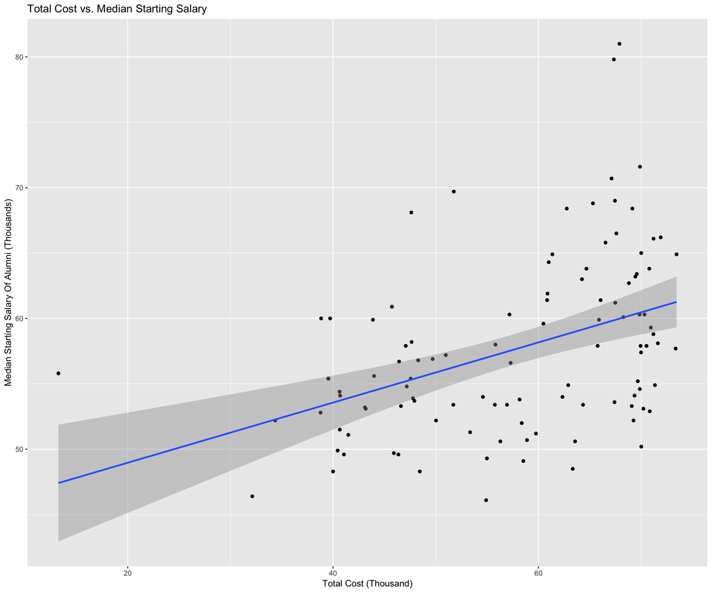

```r
plot_6 <- formatted_college_tab %>%
  ggplot(aes(x=TotalCostThousands, y=MedianStartingSalaryOfAlumniThousands)) +
    geom_point()+
    geom_smooth(method=lm)+
        labs(title="Total Cost vs. Median Starting Salary", x="Total Cost (Thousand)", y="Median Starting Salary Of Alumni (Thousands)")
plot_6
```

There appears to be a positive linear relatinoship between median starting salary and total cost of colleges. The general trends shows that the more students spend on tution and room & board, the more likely that their starting salary is higher.

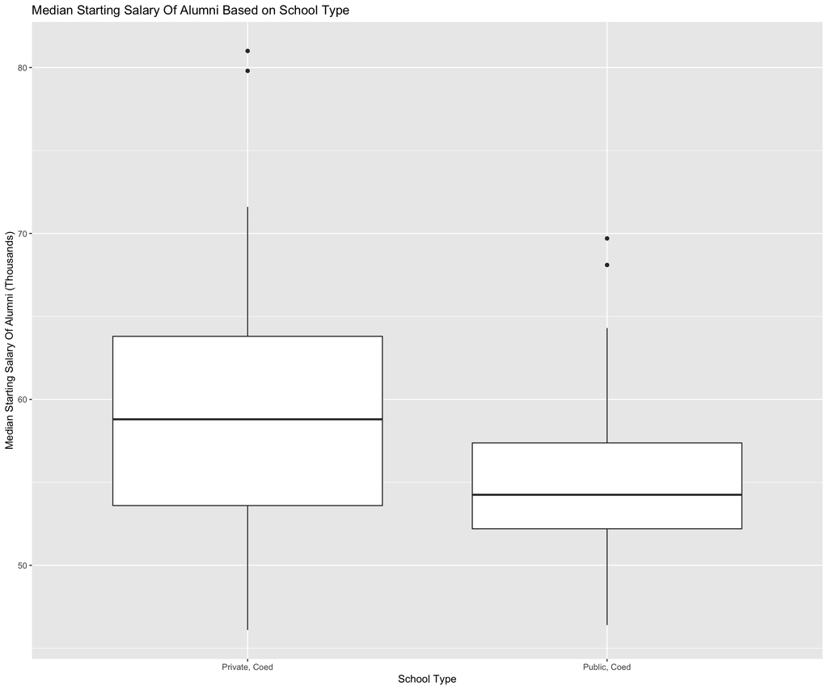

```r
plot_7 <- formatted_college_tab %>%
  ggplot(aes(x=SchoolType, y=MedianStartingSalaryOfAlumniThousands
)) +
    geom_boxplot()+
        labs(title="Median Starting Salary Of Alumni Based on School Type  ", x="School Type", y="Median Starting Salary Of Alumni (Thousands)")
plot_7
```

Between school types, private colleges seem to have greater starting salaries than public schools, based on the medians of these boxplots.

```r
 formatted_college_tab %>% group_by(Selectivity) %>%
  summarise(n())
```

```
## # A tibble: 3 x 2
##   Selectivity    `n()`
##   <fct>          <int>
## 1 More selective    63
## 2 Most selective    44
## 3 Selective          2
```